# Click Traffic Fraud Detection in Mobile Application Advertisements

Naiara de Almeida Pantuza

21/01/2020

Project developed during the DSA BigData Analystics with R and Microsoft Azure course: available on the kaggle platform

# DESCRIPTION:

Fraud risk is everywhere, but for companies that advertise online, click fraud can happen at an overwhelming volume, resulting in misleading click data and wasted money. Ad channels can drive up costs by simply clicking on the ad at a large scale. China is the largest mobile market in the world and therefore suffers from huge volumes of fradulent traffic. TalkingData, China’s largest independent big data service platform, covers over 70% of active mobile devices nationwide. They’ve built an IP blacklist and device blacklist. In this project, I am supose to build an algorithm that predicts whether a user will download an app after clicking a mobile app ad.

```r
# Setting work directory
setwd("/home/naiara/Documentos/DataScience/FCD/BigDataRAzure/Project_Fraud_Detection")
```

All datasets were downloaded in kaggle. I chose to work with 10,000,000 lines to avoid processing and storage problems on my computer.

```r
# Importing train and test datasets
Azure <- FALSE

if (Azure) {
  train <- maml.mapInputPort(1)
  test <- maml.mapInputPort(2)
}else {
  # Getting the first 10.000.000 rows of train dataset (train.zip file)
  train <- read.csv(unz("train.zip", "train.csv"))
  # Getting test dataset
  test <- read.csv(unz("test.zip", "test.csv"))
  }
```

# Data cleaning and processing

Here I proceeded with cleaning and data processing.

```r
# Checking if there are missing values.
# Only "attributed_time" has missing values, once tha apps may not be downloaded.
any(is.na(train[,-7]))
```

```
## [1] FALSE
```

```r
any(is.na(test))
```

```
## [1] FALSE
```

```r
# Modifying variable types for analysis:
# Converting categorical variables to factor
cnames <- c('ip', 'app', 'device', 'os', 'channel')
for (var in cnames) {
  train[,var] <- as.factor(train[,var])
  test[,var] <- as.factor(test[,var])
}

# Converting target variable "is_attributted" to factor
train$is_attributed <- as.factor(train$is_attributed)

# Converting temporal variables to datetime format
train$click_time <- as.POSIXct(train$click_time, tz = Sys.timezone())
train$attributed_time <- dplyr::na_if(train$attributed_time, "")
train$attributed_time <- as.POSIXct(train$attributed_time, tz = Sys.timezone())
test$click_time <- as.POSIXct(test$click_time, tz = Sys.timezone())

# Converting "click_id" from test dataset to factor
test$click_id <- as.factor(test$click_id)
```

# Visual analysis and data exploration

Here I visualized training and test datasets and their summaries.

```r
# Train dataset head
head(train)
```

```
##   X     ip app device os channel          click_time attributed_time
## 1 1  83230   3      1 13     379 2017-11-06 14:32:21            <NA>
## 2 2  17357   3      1 19     379 2017-11-06 14:33:34            <NA>
## 3 3  35810   3      1 13     379 2017-11-06 14:34:12            <NA>
## 4 4  45745  14      1 13     478 2017-11-06 14:34:52            <NA>
## 5 5 161007   3      1 13     379 2017-11-06 14:35:08            <NA>
## 6 6  18787   3      1 16     379 2017-11-06 14:36:26            <NA>
##   is_attributed
## 1             0
## 2             0
## 3             0
## 4             0
## 5             0
## 6             0
```

```r
# Test dataset head
head(test)
```

```
##   click_id     ip app device os channel          click_time
## 1        0   5744   9      1  3     107 2017-11-10 04:00:00
## 2        1 119901   9      1  3     466 2017-11-10 04:00:00
## 3        2  72287  21      1 19     128 2017-11-10 04:00:00
## 4        3  78477  15      1 13     111 2017-11-10 04:00:00
## 5        4 123080  12      1 13     328 2017-11-10 04:00:00
## 6        5 110769  18      1 13     107 2017-11-10 04:00:00
```

```r
# Train dataset summary
str(train)
```

```
## 'data.frame':    10000000 obs. of  9 variables:
##  $ X              : int  1 2 3 4 5 6 7 8 9 10 ...
##  $ ip             : Factor w/ 68740 levels "9","10","19",..: 18073 3760 7775 9962 43910 4119 22306 24856 46276 16192 ...
##  $ app            : Factor w/ 332 levels "0","1","2","3",..: 4 4 4 15 4 4 4 4 4 61 ...
##  $ device         : Factor w/ 940 levels "0","1","2","4",..: 2 2 2 2 2 2 2 2 2 2 ...
##  $ os             : Factor w/ 292 levels "0","1","2","3",..: 14 20 14 14 14 17 24 20 14 23 ...
##  $ channel        : Factor w/ 170 levels "0","3","4","5",..: 116 116 116 158 116 116 116 116 116 149 ...
##  $ click_time     : POSIXct, format: "2017-11-06 14:32:21" "2017-11-06 14:33:34" ...
##  $ attributed_time: POSIXct, format: NA NA ...
##  $ is_attributed  : Factor w/ 2 levels "0","1": 1 1 1 1 1 1 1 1 1 1 ...
```

```r
summary(train)
```

```
##        X                 ip               app              device
##  Min.   :1.0e+00   73516  :  51711   12     :1291185   1      :9381146
##  1st Qu.:2.5e+06   73487  :  51215   2      :1202534   2      : 456617
##  Median :5.0e+06   5314   :  35073   15     :1181585   3032   : 104393
##  Mean   :5.0e+06   5348   :  35004   3      :1170412   0      :  46476
##  3rd Qu.:7.5e+06   53454  :  25381   9      : 966839   59     :   1618
##  Max.   :1.0e+07   105560 :  23289   18     : 917820   40     :    462
##                    (Other):9778327   (Other):3269625   (Other):   9288
##        os             channel          click_time
##  19     :2410148   245    : 793105   Min.   :2017-11-06 14:32:21
##  13     :2199778   134    : 630888   1st Qu.:2017-11-06 17:06:58
##  17     : 531695   259    : 469845   Median :2017-11-06 20:27:57
##  18     : 483602   477    : 412559   Mean   :2017-11-06 20:15:02
##  22     : 365576   121    : 402226   3rd Qu.:2017-11-06 23:16:56
##  10     : 285907   107    : 388035   Max.   :2017-11-07 00:12:03
##  (Other):3723294   (Other):6903342
##  attributed_time               is_attributed
##  Min.   :2017-11-06 16:00:47   0:9981283
##  1st Qu.:2017-11-06 19:59:39   1:  18717
##  Median :2017-11-06 23:34:47
##  Mean   :2017-11-07 00:10:04
##  3rd Qu.:2017-11-07 02:40:27
##  Max.   :2017-11-07 15:59:53
##  NA's   :9981283
```

```r
# Teste dataset summary
summary(test)
```

```
##     click_id              ip                app              device
##  0      :       1   5348   :  182522   9      :2872176   1      :17360269
##  1      :       1   5314   :  162935   12     :2306083   2      : 1041975
##  2      :       1   73516  :   69089   3      :2201000   0      :  258152
##  3      :       1   73487  :   68866   2      :2060903   3      :   76117
##  4      :       1   53454  :   61503   18     :1923024   5      :    8279
##  5      :       1   114276 :   52649   15     :1079113   59     :    2775
##  (Other):18790463   (Other):18192905   (Other):6348170   (Other):   42902
##        os             channel           click_time
##  19     :4334532   107    : 1214650   Min.   :2017-11-10 04:00:00
##  13     :3959515   265    :  778244   1st Qu.:2017-11-10 05:27:21
##  17     : 960531   232    :  684938   Median :2017-11-10 10:03:52
##  18     : 870068   477    :  683101   Mean   :2017-11-10 09:43:00
##  22     : 773184   178    :  582524   3rd Qu.:2017-11-10 13:34:07
##  8      : 520612   153    :  566046   Max.   :2017-11-10 15:00:00
##  (Other):7372027   (Other):14280966
```

Including Plots

Check unique values for categorical variables from train dataset sample.

```r
# Loading required packages
library(ggplot2)
library(dplyr)
# Get the number of unique values for categoriacal dependent variables
uniq <- sapply(train[,cnames], function(x) {return(length(unique(x)))})
uniq_data <- data.frame(value=uniq, name=names(uniq), row.names = NULL)
```

Plotting the number of unique values for categoriacal dependent variables

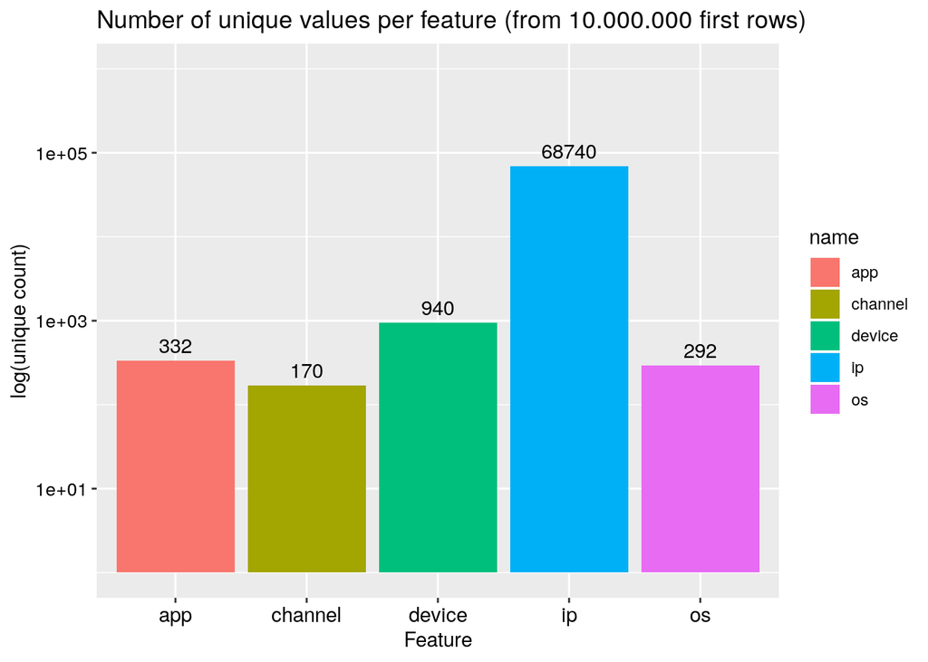

```r
# Bar plot of the number of single values
uniq_plot <- ggplot(uniq_data, aes(x=name, y=value, fill=name)) +
  geom_bar(stat = "identity") +
  ggtitle("Number of unique values per feature (from 10.000.000 first rows)") +
  xlab("Feature") +
  ylab("log(unique count)") +
  scale_y_log10(limits = c(1,1e6)) +
  geom_text(aes(label = sprintf("%d", value), y=value),  vjust = -0.5) +
  theme(axis.text.x = element_text(hjust = 0.5, size=11,color="black")) +
  theme(axis.text.y = element_text(hjust = 0.5, size=10,color="black"))

uniq_plot
```

As noted in the graph, the variables have many levels.

Summarizing attribute variables from downloaded application logs.

```r
# Filtering and summarizing attribute variables from downloaded application logs
downloaded <- train[train$is_attributed == "1", c("attributed_time", "is_attributed")]
summary(downloaded)
```

```
##  attributed_time               is_attributed
##  Min.   :2017-11-06 16:00:47   0:    0
##  1st Qu.:2017-11-06 19:59:39   1:18717
##  Median :2017-11-06 23:34:47
##  Mean   :2017-11-07 00:10:04
##  3rd Qu.:2017-11-07 02:40:27
##  Max.   :2017-11-07 15:59:53
```

Plot proportion of apps download and not download

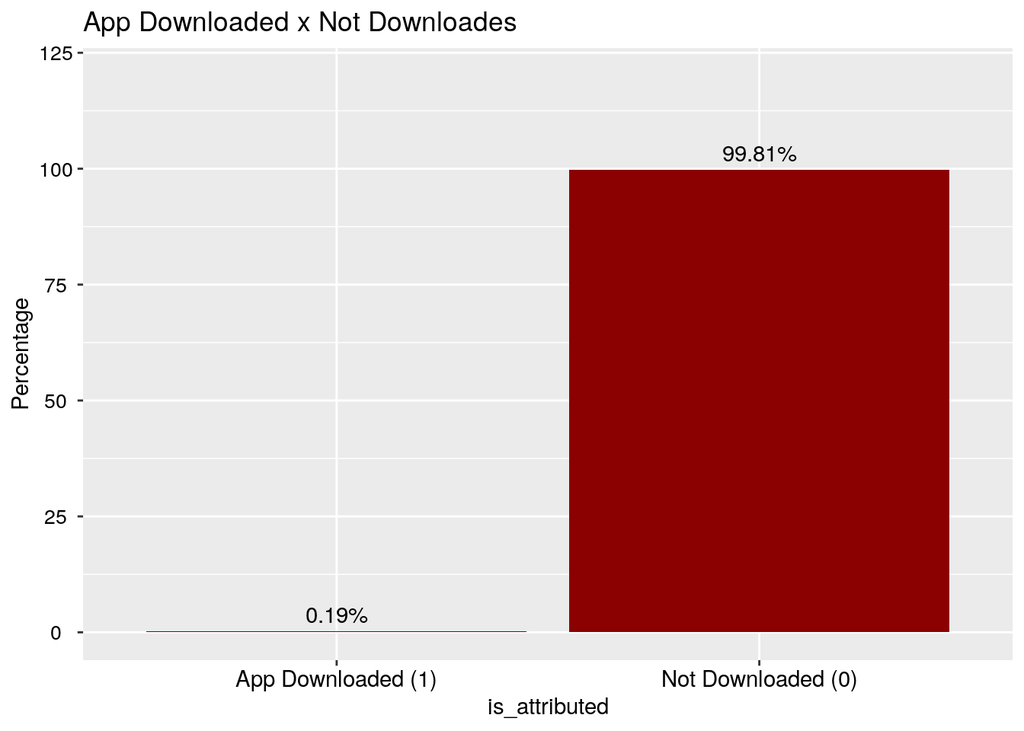

```r
# Plotting proportion of apps download and not download
app_prop <- count(group_by(train[,c("app", "is_attributed")], is_attributed))
app_prop$n <- round(app_prop$n/sum(app_prop$n)*100, 2)
app_prop$is_attributed <- c("Not Downloaded (0)", "App Downloaded (1)")

appPropPlot <- ggplot(app_prop, aes(x=is_attributed, y=n)) +
  geom_bar(stat = "identity", fill="darkred") +
  ggtitle("App Downloaded x Not Downloades") +
  ylab("Percentage") +
  ylim(0,120) +
  geom_text(aes(label = sprintf("%.2f%%", n), y=n),  vjust = -0.5) +
  theme(axis.text.x = element_text(hjust = 0.5, size=11,color="black")) +
  theme(axis.text.y = element_text(hjust = 0.5, size=10,color="black"))

appPropPlot
```

As observed less than one percent of clicks were converted to downloads.

Analysing ips frequency

```r
# Count 10 most clicked ips and their respective frequencies
temp <- as.data.frame(table(train$ip))
colnames(temp) <- c("ip", "count")
temp <- temp[order(temp$count, decreasing = TRUE),]
rownames(temp) <- 1:length(rownames(temp))
temp <- temp[1:10,]
temp
```

```
##        ip count
## 1   73516 51711
## 2   73487 51215
## 3    5314 35073
## 4    5348 35004
## 5   53454 25381
## 6  105560 23289
## 7  100275 23070
## 8  114276 22774
## 9  201182 22719
## 10 105475 22047
```

```r
# Count 10 most clicked downloaded ips and their respective frequencies
temp_downloaded <- as.data.frame(table(train[train$is_attributed == "1",]$ip))
colnames(temp_downloaded) <- c("downloaded_ip", "count_downloads")
temp_downloaded <- temp_downloaded[order(temp_downloaded$count, decreasing = TRUE),]
rownames(temp_downloaded) <- 1:length(rownames(temp_downloaded))
temp_downloaded <- temp_downloaded[1:10,]
temp_downloaded
```

```
##    downloaded_ip count_downloads
## 1          73487              56
## 2          73516              54
## 3           5314              26
## 4         201182              25
## 5           5348              24
## 6         100275              23
## 7         105475              22
## 8         105560              16
## 9          44744              15
## 10        123994              14
```

```r
# Checking coincide between 10 most clicked apss and the 10 most clicked downloaded apss
table(c(temp$ip,temp_downloaded$downloaded_ip))
```

```
##
##  1162  1173  9778 11715 16005 16012 21708 22868 22885 24864 26950 63053
##     2     2     1     1     2     2     2     2     2     1     1     2
```

Eight ips with the highest number of clicks were most downloaded.

Get summary of downloaded app dataset

```r
# Get statistic data from downloaded ip dataset
# Minimum, maximum, average, median, quartiles.
summary(as.integer(train[train$is_attributed == "1", "ip"]))
```

```
##    Min. 1st Qu.  Median    Mean 3rd Qu.    Max.
##       5   16336   32828   33468   50388   68737
```

```r
# Count values
length(as.numeric(train[train$is_attributed == "1", "ip"]))
```

```
## [1] 18717
```

```r
# Count unique values
length(unique(as.integer(train[train$is_attributed == "1", "ip"])))
```

```
## [1] 16112
```

Analysing Most Popular IPs Getting the 300 most clicked ips, respective count of clickes and conversion rates (clicks converted to download).

Exibing table results:

```r
# Converting "is_attributed" to numeric temporarily to plotting
train$is_attributed <- as.numeric(train$is_attributed)-1

# Conversion Rates over Counts of 300 Most Popular IPs
# Exibing table results
count_rate <- train %>%
  group_by(ip) %>%
  summarise(click_count=n(), prop_downloaded = round(sum(is_attributed)/n(), 4)) %>%
  arrange(desc(click_count)) %>%
  slice(1:300) %>%
  data.frame()

count_rate
```

```
##         ip click_count prop_downloaded
## 1    73516       51711          0.0010
## 2    73487       51215          0.0011
## 3     5314       35073          0.0007
## 4     5348       35004          0.0007
## 5    53454       25381          0.0001
## 6   105560       23289          0.0007
## 7   100275       23070          0.0010
## 8   114276       22774          0.0001
## 9   201182       22719          0.0011
## 10  105475       22047          0.0010
## 11   95766       21966          0.0005
## 12   26995       19166          0.0005
## 13  209663       17605          0.0005
## 14   43793       15398          0.0008
```

[output cut: 286 more lines]

Exibing plot results:

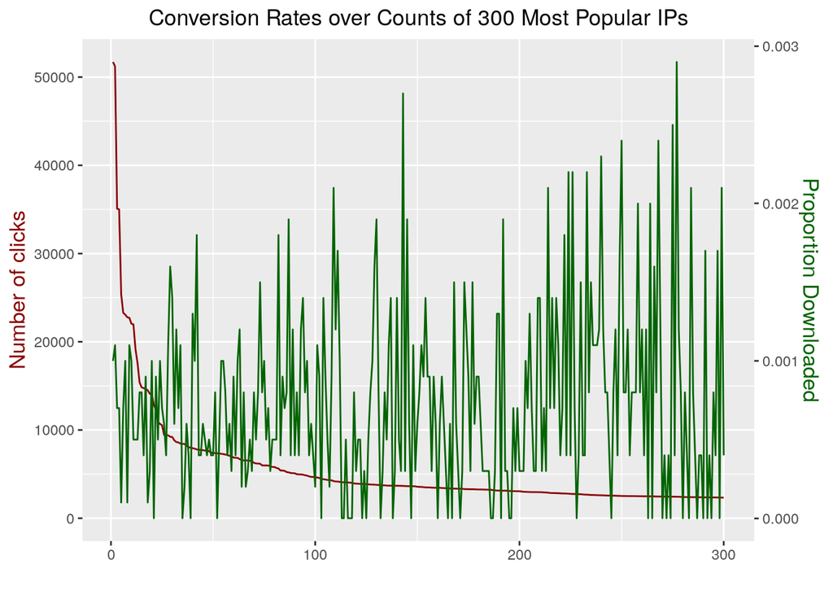

```r
# Obtain the coefficient so that both y axes are on the same scale
count_rate$num <- seq(1:nrow(count_rate))
MAX <- max(count_rate$click_count)
mx <- max(count_rate$prop_downloaded)
coef <- mx/MAX

# Disabling scientific notation in R
options(scipen = 999)

# Plotting Conversion Rates over Counts of 300 Most Popular IPs
ggplot(count_rate, aes(x=num)) +
  geom_line(aes(x=num, y=click_count), color="darkred") +
  geom_line(aes(x=num, y=prop_downloaded/coef), color="darkgreen") +
  ggtitle("Conversion Rates over Counts of 300 Most Popular IPs") +
  scale_y_continuous(
    # Features of the first axis
    name = "Number of clicks",
    # Add a second axis and specify its features
    sec.axis = sec_axis(~.*coef, name="Proportion Downloaded")
  ) +
  theme(
    axis.title.y = element_text(color = "darkred", size=13),
    axis.title.y.right = element_text(color = "darkgreen", size=13),
    plot.title = element_text(hjust = 0.5)
  ) +
  xlab("")
```

According to the graph, the number of clicks and conversion rate for ips are not significantly correlated.

Repeating the previous analysis for applications, operating systems, devices and channels.

Getting the 100 most clicked apps, respective count of clickes and conversion rates (clicks converted to download) and exibing table and plot results:

```r
# Conversion Rates over Counts of 100 Most Popular Apps
count_rate <- train %>%
  group_by(app) %>%
  summarise(click_count=n(), prop_downloaded = round(sum(is_attributed)/n(), 4)) %>%
  arrange(desc(click_count)) %>%
  slice(1:100) %>%
  data.frame()

count_rate
```

```
##     app click_count prop_downloaded
## 1    12     1291185          0.0001
## 2     2     1202534          0.0004
## 3    15     1181585          0.0003
## 4     3     1170412          0.0006
## 5     9      966839          0.0009
## 6    18      917820          0.0004
## 7    14      507491          0.0005
## 8     1      391508          0.0003
## 9     8      364361          0.0014
## 10   21      223823          0.0001
## 11   13      203332          0.0001
## 12   20      174792          0.0020
## 13   24      156247          0.0006
## 14   11      152367          0.0015
```

[output cut: 86 more lines]

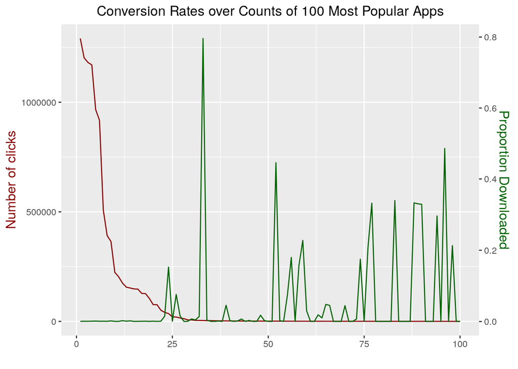

```r
# Obtain the coefficient so that both y axes are on the same scale
count_rate$num <- seq(1:nrow(count_rate))
MAX <- max(count_rate$click_count)
mx <- max(count_rate$prop_downloaded)
coef <- mx/MAX

# Plotting Conversion Rates over Counts of 100 Most Popular Apps
ggplot(count_rate, aes(x=num)) +
  geom_line(aes(x=num, y=click_count), color="darkred") +
  geom_line(aes(x=num, y=prop_downloaded/coef), color="darkgreen") +
  ggtitle("Conversion Rates over Counts of 100 Most Popular Apps") +
  scale_y_continuous(
    # Features of the first axis
    name = "Number of clicks",
    # Add a second axis and specify its features
    sec.axis = sec_axis(~.*coef, name="Proportion Downloaded")
  ) +
  theme(
    axis.title.y = element_text(color = "darkred", size=13),
    axis.title.y.right = element_text(color = "darkgreen", size=13),
    plot.title = element_text(hjust = 0.5)
  ) +
  xlab("")
```

According to the graph, the number of clicks and conversion rate for apps are not significantly correlated.

Getting the 100 most clicked Operational Systems, respective count of clickes and conversion rates (clicks converted to download) and exibing table and plot results:

```r
# Conversion Rates over Counts of Most Popular Operational Systems
count_rate <- train %>%
  group_by(os) %>%
  summarise(click_count=n(), prop_downloaded = round(sum(is_attributed)/n(), 4)) %>%
  arrange(desc(click_count)) %>%
  slice(1:100) %>%
  data.frame()

count_rate
```

```
##      os click_count prop_downloaded
## 1    19     2410148          0.0015
## 2    13     2199778          0.0013
## 3    17      531695          0.0012
## 4    18      483602          0.0011
## 5    22      365576          0.0017
## 6    10      285907          0.0010
## 7     8      279549          0.0010
## 8     6      242799          0.0026
## 9     9      239377          0.0007
## 10   25      232143          0.0012
## 11   15      230832          0.0009
## 12   20      223820          0.0009
## 13   16      166165          0.0013
## 14   37      151274          0.0005
```

[output cut: 86 more lines]

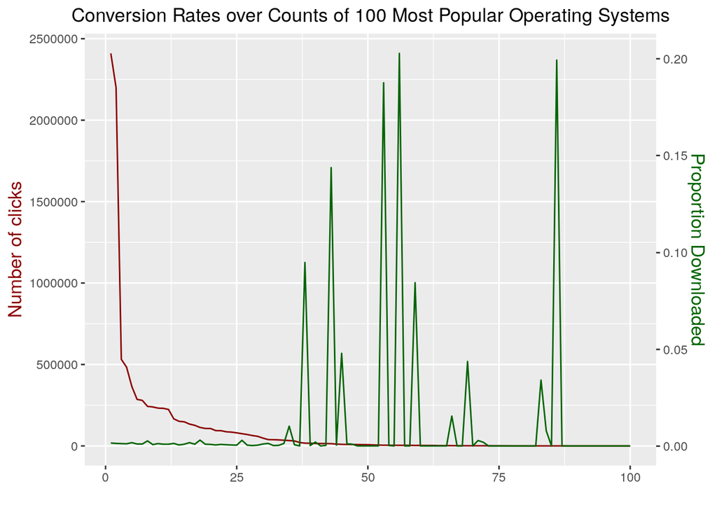

```r
# Obtain the coefficient so that both y axes are on the same scale
count_rate$num <- seq(1:nrow(count_rate))
MAX <- max(count_rate$click_count)
mx <- max(count_rate$prop_downloaded)
coef <- mx/MAX

# Plotting Conversion Rates over Counts of 100 Most Popular Operating Systems
ggplot(count_rate, aes(x=num)) +
  geom_line(aes(x=num, y=click_count), color="darkred") +
  geom_line(aes(x=num, y=prop_downloaded/coef), color="darkgreen") +
  ggtitle("Conversion Rates over Counts of 100 Most Popular Operating Systems") +
  scale_y_continuous(
    # Features of the first axis
    name = "Number of clicks",
    # Add a second axis and specify its features
    sec.axis = sec_axis(~.*coef, name="Proportion Downloaded")
  ) +
  theme(
    axis.title.y = element_text(color = "darkred", size=13),
    axis.title.y.right = element_text(color = "darkgreen", size=13),
    plot.title = element_text(hjust = 0.5)
  ) +
  xlab("")
```

According to the graph, the number of clicks and conversion rate for Operational Systems are not significantly correlated.

Getting the 100 most clicked devices, respective count of clickes and conversion rates (clicks converted to download) and exibing table and plot results:

```r
# Conversion Rates and Counts of Most Popular by device
count_rate <- train %>%
  group_by(device) %>%
  summarise(click_count=n(), prop_downloaded = round(sum(is_attributed)/n(), 4)) %>%
  arrange(desc(click_count)) %>%
  slice(1:100) %>%
  data.frame()

count_rate
```

```
##     device click_count prop_downloaded
## 1        1     9381146          0.0013
## 2        2      456617          0.0002
## 3     3032      104393          0.0000
## 4        0       46476          0.0920
## 5       59        1618          0.0012
## 6       40         462          0.2468
## 7        6         458          0.2227
## 8       16         334          0.2425
## 9       18         247          0.2267
## 10      33         204          0.1961
## 11      21         190          0.2421
## 12     154         151          0.1788
## 13    3033         151          0.1788
## 14      37         145          0.1931
```

[output cut: 86 more lines]

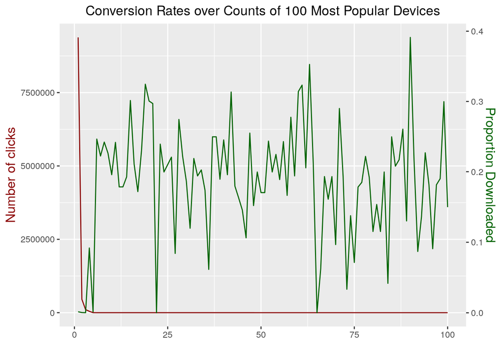

```r
# Obtain the coefficient so that both y axes are on the same scale
count_rate$num <- seq(1:nrow(count_rate))
MAX <- max(count_rate$click_count)
mx <- max(count_rate$prop_downloaded)
coef <- mx/MAX

# Plotting
ggplot(count_rate, aes(x=num)) +
  geom_line(aes(x=num, y=click_count), color="darkred") +
  geom_line(aes(x=num, y=prop_downloaded/coef), color="darkgreen") +
  ggtitle("Conversion Rates over Counts of 100 Most Popular Devices") +
  scale_y_continuous(
    # Features of the first axis
    name = "Number of clicks",
    # Add a second axis and specify its features
    sec.axis = sec_axis(~.*coef, name="Proportion Downloaded")
  ) +
  theme(
    axis.title.y = element_text(color = "darkred", size=13),
    axis.title.y.right = element_text(color = "darkgreen", size=13),
    plot.title = element_text(hjust = 0.5)
  ) +
  xlab("")
```

According to the graph, the number of clicks and conversion rate for devices are not significantly correlated.

Getting the 100 most clicked channels, respective count of clickes and conversion rates (clicks converted to download) and exibing table and plot results:

```r
# Conversion Rates over Counts of Most Popular Channels
count_rate <- train %>%
  group_by(channel) %>%
  summarise(click_count=n(), prop_downloaded = round(sum(is_attributed)/n(), 4)) %>%
  arrange(desc(click_count)) %>%
  slice(1:100) %>%
  data.frame()

count_rate
```

```
##     channel click_count prop_downloaded
## 1       245      793105          0.0001
## 2       134      630888          0.0006
## 3       259      469845          0.0007
## 4       477      412559          0.0001
## 5       121      402226          0.0003
## 6       107      388035          0.0004
## 7       145      348862          0.0012
## 8       153      296832          0.0002
## 9       205      279720          0.0002
## 10      178      269720          0.0001
## 11      265      236949          0.0002
## 12      128      223205          0.0001
## 13      140      222096          0.0003
## 14      459      214060          0.0002
```

[output cut: 86 more lines]

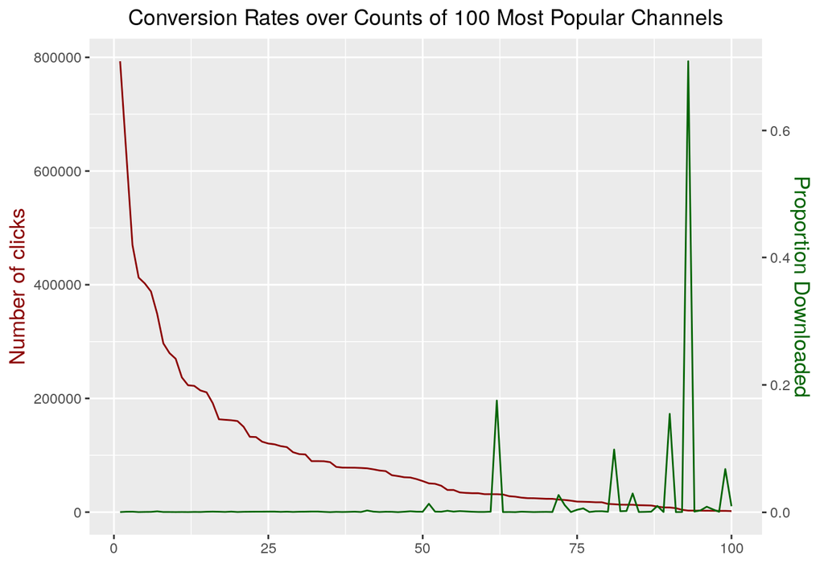

```r
# Obtain the coefficient so that both y axes are on the same scale
count_rate$num <- seq(1:nrow(count_rate))
MAX <- max(count_rate$click_count)
mx <- max(count_rate$prop_downloaded)
coef <- mx/MAX

# Plotting
ggplot(count_rate, aes(x=num)) +
  geom_line(aes(x=num, y=click_count), color="darkred") +
  geom_line(aes(x=num, y=prop_downloaded/coef), color="darkgreen") +
  ggtitle("Conversion Rates over Counts of 100 Most Popular Channels") +
  scale_y_continuous(
    # Features of the first axis
    name = "Number of clicks",
    # Add a second axis and specify its features
    sec.axis = sec_axis(~.*coef, name="Proportion Downloaded")
  ) +
  theme(
    axis.title.y = element_text(color = "darkred", size=13),
    axis.title.y.right = element_text(color = "darkgreen", size=13),
    plot.title = element_text(hjust = 0.5)
  ) +
  xlab("")
```

According to the graph, the number of clicks and conversion rate for channels are not significantly correlated.

## Time Patterns

The analysis of temporal patterns will be made with the sample provided by the kaggle. The first lines of the dataset are organized by time and therefore are not random. Thus, they are inappropriate for detecting temporal patterns.

Getting and treating the random sample train dataset: converting datetime variables to POSIXct format and rounding “click_time” variable’s hours.

```r
# Importing a random training dataset sample for time pattern analysis
sampleTrain <- read.csv("train_sample.csv")

head(sampleTrain)
```

```
##       ip app device os channel          click_time attributed_time
## 1  87540  12      1 13     497 2017-11-07 09:30:38
## 2 105560  25      1 17     259 2017-11-07 13:40:27
## 3 101424  12      1 19     212 2017-11-07 18:05:24
## 4  94584  13      1 13     477 2017-11-07 04:58:08
## 5  68413  12      1  1     178 2017-11-09 09:00:09
## 6  93663   3      1 17     115 2017-11-09 01:22:13
##   is_attributed
## 1             0
## 2             0
## 3             0
## 4             0
## 5             0
## 6             0
```

```r
#convert click_time and attributed_time to time series
sampleTrain$attributed_time <- dplyr::na_if(sampleTrain$attributed_time, "")
sampleTrain$attributed_time <- as.POSIXct(sampleTrain$attributed_time, tz = Sys.timezone())
sampleTrain$click_time <- as.POSIXct(sampleTrain$click_time, tz = Sys.timezone())

# Convert "is_attributed to numeric
sampleTrain$is_attributed <- as.numeric(sampleTrain$is_attributed)

#round the time to nearest hour
sampleTrain$click_round <- lubridate::round_date(sampleTrain$click_time, "hour")
```

Temporal anaylis: checking for hourly patterns by tables and plotting graphs.

```r
# Checking for hourly patterns
count_rate <- sampleTrain[,c("click_round", "is_attributed")] %>%
  group_by(click_round) %>%
  summarise(click_count=n(), conversion_rate = round(sum(is_attributed)/n(), 4)) %>%
  data.frame()

head(count_rate, 100)
```

```
##            click_round click_count conversion_rate
## 1  2017-11-06 16:00:00         684          0.0000
## 2  2017-11-06 17:00:00         921          0.0022
## 3  2017-11-06 18:00:00         523          0.0000
## 4  2017-11-06 19:00:00         367          0.0000
## 5  2017-11-06 20:00:00         251          0.0000
## 6  2017-11-06 21:00:00         235          0.0085
## 7  2017-11-06 22:00:00         396          0.0000
## 8  2017-11-06 23:00:00         955          0.0021
## 9  2017-11-07 00:00:00        1649          0.0018
## 10 2017-11-07 01:00:00        1928          0.0031
## 11 2017-11-07 02:00:00        1715          0.0035
## 12 2017-11-07 03:00:00        1692          0.0053
## 13 2017-11-07 04:00:00        1861          0.0005
## 14 2017-11-07 05:00:00        1843          0.0016
```

[output cut: 59 more lines]

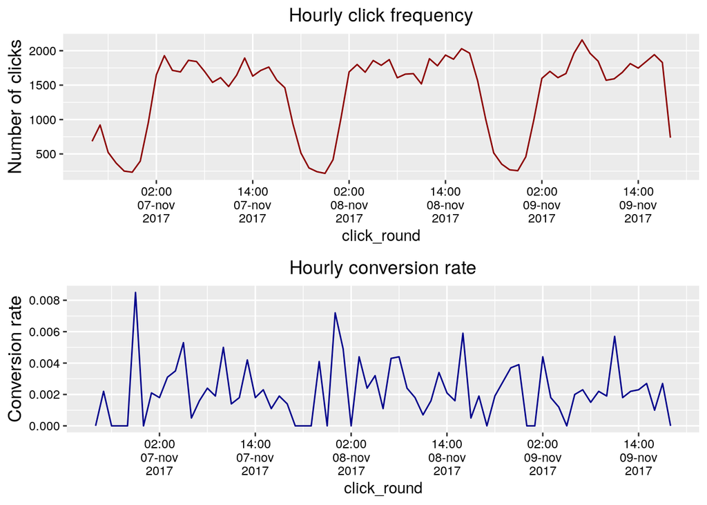

```r
# Plotting
require(gridExtra)
# Plotting hourly clicks
plot1 <- ggplot(count_rate, aes(x=click_round)) +
  geom_line(aes(x=click_round, y=click_count), color="darkred") +
  ggtitle("Hourly click frequency") +
  scale_y_continuous(name = "Number of clicks") +
  scale_x_datetime(labels = scales::date_format("%H:%M\n%d-%b\n%Y"), date_breaks = "12 hours") +
  theme(
    axis.title.y = element_text(color = "black", size=13),
    axis.text.x= element_text(color = "black"),
    axis.text.y= element_text(color = "black"),
    plot.title = element_text(hjust = 0.5)
  )

# Plotting hourly conversion rate
plot2 <- ggplot(count_rate, aes(x=click_round)) +
  geom_line(aes(x=click_round, y=conversion_rate), color="darkblue") +
  ggtitle("Hourly conversion rate") +
  scale_y_continuous(name = "Conversion rate") +
  scale_x_datetime(labels = scales::date_format("%H:%M\n%d-%b\n%Y"), date_breaks = "12 hours",
                   limits = ) +
  theme(
    axis.title.y = element_text(color = "black", size=13),
    axis.text.x= element_text(color = "black"),
    axis.text.y= element_text(color = "black"),
    plot.title = element_text(hjust = 0.5)
  )

grid.arrange(plot1, plot2, nrow = 2)
```

Looking at the graph, I noticed that the click count and conversion rate for downloads do not appear to be significantly correlated.

Extracting hour from “click_time” variable and getting the number of clicks and conversion rate by hour. Exibing table and graphs:

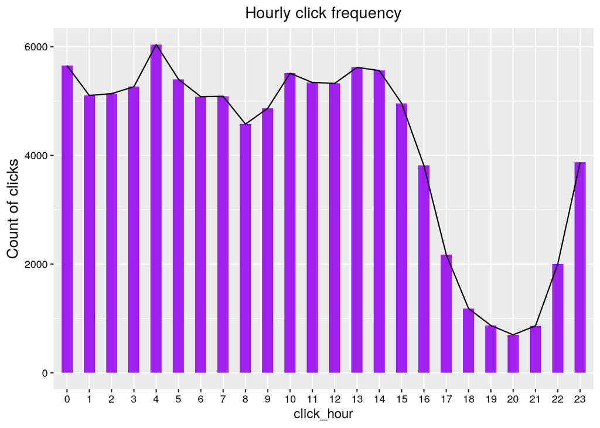

```r
# Extract hour from "click_time" and add to sample train dataset
sampleTrain$click_hour <- as.factor(lubridate::hour(sampleTrain$click_time))

# Getting number of clicks by hour
count_rate <- sampleTrain[,c("click_hour", "is_attributed")] %>%
  group_by(click_hour) %>%
  summarise(click_count=n(), conversion_rate = round(mean(is_attributed), 4)) %>%
  data.frame()

# Visualizing data.frame
View(count_rate)

# Plotting number of clicks by hour
ggplot(count_rate, aes(x=click_hour, y=click_count)) +
  geom_bar(stat = "identity", fill="purple", width = 0.5) +
  geom_line( aes(x=as.numeric(click_hour), y=click_count)) +
  ggtitle("Hourly click frequency") +
  scale_y_continuous(name = "Count of clicks") +
  theme(
    axis.title.y = element_text(color = "black", size=13),
    axis.text.x= element_text(color = "black"),
    axis.text.y= element_text(color = "black"),
    plot.title = element_text(hjust = 0.5)
  )
```

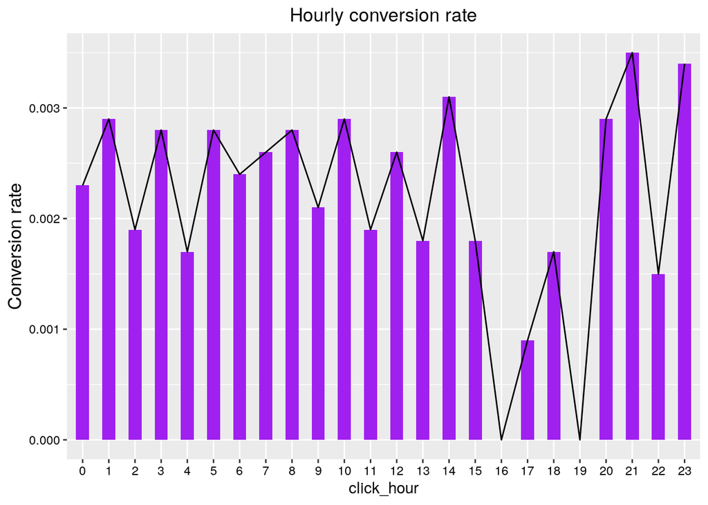

```r
# Plotting hourly conversion rate
ggplot(count_rate, aes(x=click_hour, y=conversion_rate)) +
  geom_bar(stat = "identity", fill="purple", width = 0.5) +
  geom_line( aes(x=as.numeric(click_hour), y=conversion_rate)) +
  ggtitle("Hourly conversion rate") +
  scale_y_continuous(name = "Conversion rate") +
  theme(
    axis.title.y = element_text(color = "black", size=13),
    axis.text.x= element_text(color = "black"),
    axis.text.y= element_text(color = "black"),
    plot.title = element_text(hjust = 0.5)
  )
```

Plotting conversion rate and count of clicks to check if both variables correlate:

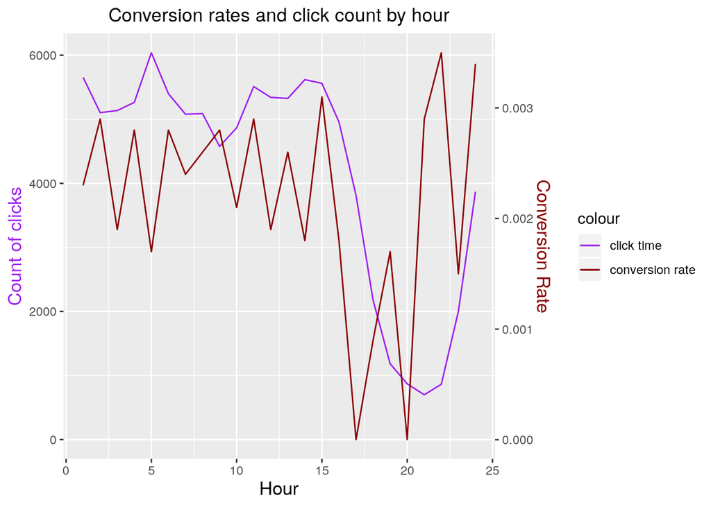

```r
# Plotting conversion rate and count of clicks to check if the variables correlate
# Obtain the coefficient so that both y axes are on the same scale
MAX <- max(count_rate$click_count)
mx <- max(count_rate$conversion_rate)
coef <- mx/MAX

# Plotting
ggplot(count_rate, aes(x=num)) +
  geom_line(aes(x=as.numeric(click_hour), y=click_count, color="click time")) +
  geom_line(aes(x=as.numeric(click_hour), y=conversion_rate/coef, color="conversion rate")) +
  ggtitle("Conversion rates and click count by hour") +
  scale_y_continuous(
    # Features of the first axis
    name = "Count of clicks",
    # Add a second axis and specify its features
    sec.axis = sec_axis(~.*coef, name="Conversion Rate")
  ) + xlab("Hour") +
  theme(
    axis.title.y = element_text(color = "purple", size=13),
    axis.title.x = element_text(color = "black", size=13),
    axis.title.y.right = element_text(color = "darkred", size=13),
    plot.title = element_text(hjust = 0.5)
  ) +
  scale_color_manual(values = c("purple", "darkred"))
```

According to the graph, the variables appear to have a weak correlation.

Here, I check the time difference between click_time and it’s conversion to download (attributed_time) on sample train dataset: visualizing and summarizing

```r
# Checking the time difference between clicking add and download it
sampleTrain$timeDiff <- hms::as_hms(sampleTrain$attributed_time - sampleTrain$click_time)

# Checking first rows and the time passaed between click and download
head(sampleTrain[sampleTrain$is_attributed == 1,], 15)
```

```
##          ip app device os channel          click_time     attributed_time
## 285  224120  19      0 29     213 2017-11-08 02:22:13 2017-11-08 02:22:38
## 482  272894  10      1  7     113 2017-11-08 06:10:05 2017-11-08 06:10:37
## 1209  79001  19      0  0     213 2017-11-07 09:54:22 2017-11-07 11:59:05
## 1342 131029  19      0  0     343 2017-11-09 10:58:46 2017-11-09 11:52:01
## 1413  40352  19      0  0     213 2017-11-07 22:19:03 2017-11-08 01:55:02
## 1667  48733  35      1 18     274 2017-11-07 12:25:50 2017-11-07 13:10:30
## 1772 330861  35      1 22      21 2017-11-08 18:54:44 2017-11-08 22:39:52
## 1918 309576   5      1 32     113 2017-11-09 08:47:51 2017-11-09 08:47:55
## 3915 220571  71      1 25       3 2017-11-08 04:35:21 2017-11-08 04:37:46
## 3993 240051  35      1 19      21 2017-11-08 08:07:13 2017-11-08 09:46:42
## 4301 110652  19     16  0     213 2017-11-09 08:15:34 2017-11-09 09:30:19
## 4425 252612   5      1 31     113 2017-11-07 20:21:11 2017-11-07 20:21:42
## 4565  48072  19     21 24     213 2017-11-07 05:17:29 2017-11-07 06:49:01
## 4604  12506  62      1 19      21 2017-11-08 05:56:57 2017-11-08 08:56:58
```

[output cut: 17 more lines]

```r
# Getting time passed summary
as.data.frame(lapply(summary(as.numeric(sampleTrain[sampleTrain$is_attributed == 1,
                                                    "timeDiff"])), hms::as_hms))
```

```
##       Min.   X1st.Qu.   Median            Mean   X3rd.Qu.     Max.
## 1 00:00:02 00:00:52.5 00:03:18 01:14:59.572687 01:21:27.5 12:52:21
```

Here I check the time difference between click_time and it’s conversion to download (attributed_time) on first 10.000.000 rows of train dataset:

```r
# Checking the time difference between clicking add and download it
# on the first 10.000.000 rows of train datset
train$timeDiff <- hms::as_hms(train$attributed_time - train$click_time)

# Summary
as.data.frame(lapply(summary(as.numeric(train[train$is_attributed == 1,
                                                    "timeDiff"])), hms::as_hms))
```

```
##       Min. X1st.Qu.   Median            Mean X3rd.Qu.     Max.
## 1 00:00:00 00:01:26 00:25:03 03:48:02.893733 06:34:14 23:52:38
```

The difference varias from 0 to almost 24 hours (one day) on first rows of train dataset.

# Feature Selection

In this script the selection of characteristics is performed for the creation of the model. I used randomForest algorithm to measure variables’ importance. So, I converted categorical dependent variables to integer. Due to my machine’s processing and memory limitations, I worked with random samples from the training and test datasets to build and evaluate the model.

```r
# Set seed
set.seed(123)

# Feature selection using randomForest package
# load the library
library(randomForest)
```

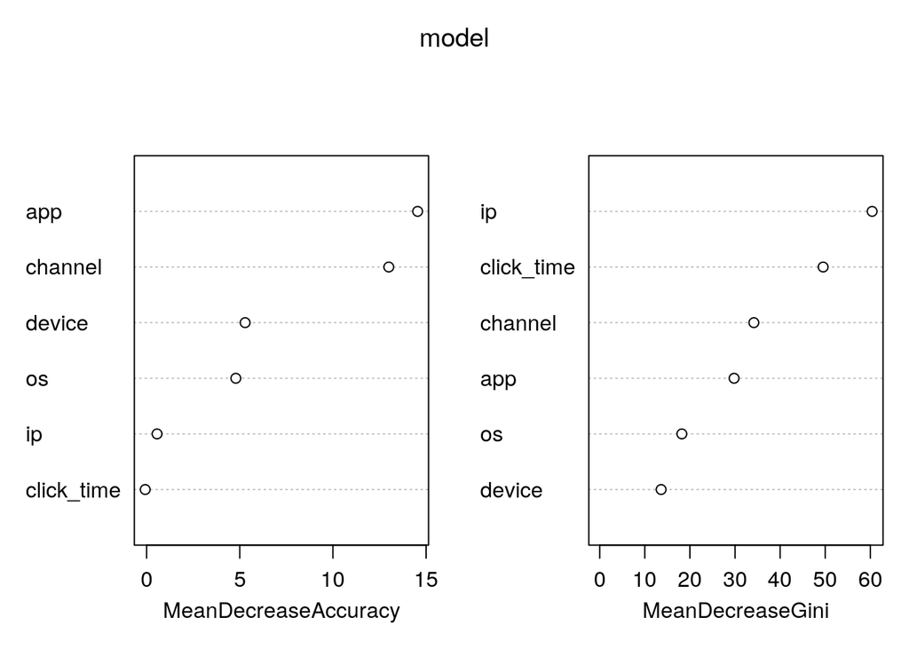

```r
# Converting target variable to factor
train$is_attributed <- as.factor(train$is_attributed)

# Converting dependents variables to integer to run random forest algorithm
cnames <- c('ip', 'app', 'device', 'os', 'channel')
for (var in cnames) {
  train[,var] <- as.integer(train[,var])
  test[,var] <- as.integer(test[,var])
}

# Due to my machine's processing and memory limitations, I will work with random samples
# from the training and test datasets to build and evaluate the model
index <- sample(1:nrow(train), 100000)
train_data <- train[index,]

# Creating random forest model measuring importance
model <- randomForest( is_attributed ~ ip + app + device + os + channel + click_time,
                       data = train_data,
                       ntree = 100,
                       nodesize = 10,
                       importance = TRUE)

# Plotting estimate variable importance
varImpPlot(model)
```

The dataset has few variables so I will make the first version of the model using all but (attribute_time).

# Model construction and evaluation

In this script, the prediction model is created. Then, the prediction for the test data set is made and the model is evaluated. Due to my machine’s processing and memory limitations, I will work with random samples from the training and test datasets on proportion 70% training to 30% test to build and evaluate the model. I used random forest algorithm again to build the model. Then I assessed its efficiency with a matrix of confusion, and accuracy. “sample_submission.csv” file contains correct classification for test dataset.

Getting samples of train and test datasets and and treating it.

```r
# Getting the correct classification for test dataset
test_result <- read.csv("sample_submission.csv")

# Getting smaller samples of trein and test datasets
# on proportion 70% training to 30% test
index <- sample(1:nrow(train), 100000)
train_data <- train[index, ]

str(train_data)
```

```
## 'data.frame':    100000 obs. of  10 variables:
##  $ X              : int  950526 4629928 1497650 4446263 4027508 9918896 7434971 5723399 492647 4650946 ...
##  $ ip             : int  1920 24864 3438 16667 9159 8045 43030 55274 15605 15727 ...
##  $ app            : int  13 14 9 3 4 7 19 13 13 3 ...
##  $ device         : int  2 2 2 2 2 2 2 2 2 2 ...
##  $ os             : int  19 7 14 7 7 18 20 14 14 21 ...
##  $ channel        : int  48 157 41 144 138 30 16 76 72 136 ...
##  $ click_time     : POSIXct, format: "2017-11-06 16:20:44" "2017-11-06 19:35:50" ...
##  $ attributed_time: POSIXct, format: NA NA ...
##  $ is_attributed  : Factor w/ 2 levels "0","1": 1 1 1 1 1 1 1 1 1 1 ...
##  $ timeDiff       : 'hms' num  NA NA NA NA ...
##   ..- attr(*, "units")= chr "secs"
```

```r
index <- sample(1:nrow(test), 42857)
test_data <- test[index,]
test_data <- merge(test_data, test_result[index,], by.x="click_id", by.y="click_id")
test_data$click_id <- NULL

# Converting dependent variables to integer before creating model
# using random forest algorithm
cnames <- c('ip', 'app', 'device', 'os', 'channel')
for (var in cnames) {
  train_data[,var] <- as.integer(train_data[,var])
  test_data[,var] <- as.integer(test_data[,var])
}

# Emphasize the levels of the target variable
# since I used a random sample to build the model
levels(train_data$is_attributed) <- c("0", "1")
```

Creating and printing model:

```r
# Creating model
model <- randomForest( is_attributed ~ ip + app + device + os + channel + click_time,
                       data = train_data,
                       ntree = 100,
                       nodesize = 10)

# Print model
print(model)
```

```
##
## Call:
##  randomForest(formula = is_attributed ~ ip + app + device + os +      channel + click_time, data = train_data, ntree = 100, nodesize = 10)
##                Type of random forest: classification
##                      Number of trees: 100
## No. of variables tried at each split: 2
##
##         OOB estimate of  error rate: 0.16%
## Confusion matrix:
##       0  1   class.error
## 0 99803  9 0.00009016952
## 1   154 34 0.81914893617
```

Predicting classification using sample test dataset and building a data.frame containing columns: expected results and correct results.

```r
# Generating predictions in test data
pred <- data.frame(observed = test_data$is_attributed,
                        predicted = predict(model, newdata = test_data[,1:6]))

pred$observed <- as.factor(pred$observed)
levels(pred$observed) = c("0", "1")
levels(pred$predicted) = c("0", "1")

# Visualizing the results
View(pred)
```

Evaluating model

```r
# Evaluating the model
# Generating a confusion matrix
caret::confusionMatrix(pred$observed, pred$predicted)
```

```
## Confusion Matrix and Statistics
##
##           Reference
## Prediction     0     1
##          0 42835    22
##          1     0     0
##
##                Accuracy : 0.9995
##                  95% CI : (0.9992, 0.9997)
##     No Information Rate : 0.9995
##     P-Value [Acc > NIR] : 0.5564
##
##                   Kappa : 0
##
##  Mcnemar's Test P-Value : 0.000007562
##
##             Sensitivity : 1.0000
##             Specificity : 0.0000
##          Pos Pred Value : 0.9995
##          Neg Pred Value :    NaN
##              Prevalence : 0.9995
##          Detection Rate : 0.9995
##    Detection Prevalence : 1.0000
##       Balanced Accuracy : 0.5000
##
##        'Positive' Class : 0
##
```